# MLB player aging

Author

Arthur Andrews

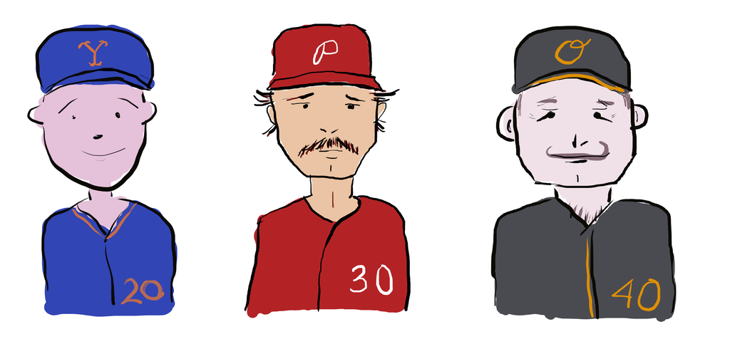

# Goals

- Study the aging of MLB player performance
- Reveal the bias of estimating aging curves with simple aggregation
- Demonstrate a statistics model for aging using splines and mixed effects modeling
- Show some players whose aging curves are unusual or exceptional

# Purpose

This is just a hobby project.

# Tools

- `R` (programming language)
- `baseballr` (an R interface to MLB data)
- `quarto` (publishing documents from code)
- `GitHub Pages` (hosting code and web pages)

# Dependencies

```r
library(tidyverse)
library(broom.mixed)
library(janitor)
library(splines)
library(factoextra)
library(reactable)
library(ggsci)
library(magrittr, include.only = "set_rownames")
library(lme4, exclude = c("expand", "pack", "unpack"))
library(htmltools, include.only = "css")
library(pracma, include.only = c("fzero", "fderiv"))

theme_set(theme_bw(base_size = 12))
```

```r
load("data/hitting_stats.RData")
```

# Declare functions

For predicting with a spline function and predicting with the stats model.

```r
predict_splines <- function(x, model) {
  x |>
    predict(object = model) |>
    as_tibble() |>
    mutate(across(everything(), as.numeric)) |>
    rename_with(.fn = \(x) str_c("spline", x))
}


add_splines <- function(hit, model) {
  hit |>
    select(-contains("spline")) |>
    bind_cols(
      hit$centered_age |>
        predict_splines(model)
    )
}


add_prediction <- function(hit, model, ...) {
  hit$pred_ops <- predict(model, hit, ...)
  hit
}


tabulate <- partial(
  reactable,
  fullWidth = FALSE, highlight = TRUE, style = css(fontSize = "90%")
)
```

# Data set

I accessed MLB hitter data from 2010-2023 using the excellent `baseballr` package, which offers convenient interfaces to the Statscast APIs to Baseball Reference data.

I include - seasons with at least 200 plate appearances - and hitters with at least 5 seasons

The data loaded by this notebook was first prepared in a separate script that you may find in the code repository: `query_mlb.R`.

```r
hit <- hit |>
  filter(n_seasons >= 5)
```

```r
hit |>
  group_by(season) |>
  summarize(rows = n(), hitters = n_distinct(id)) |>
  tabulate(defaultPageSize = 15)
```

| season | rows | hitters |
| --- | --- | --- |
| 2010 | 157 | 157 |
| 2011 | 178 | 178 |
| 2012 | 206 | 206 |
| 2013 | 239 | 239 |
| 2014 | 267 | 267 |
| 2015 | 280 | 280 |
| 2016 | 270 | 270 |
| 2017 | 269 | 269 |
| 2018 | 256 | 256 |
| 2019 | 233 | 233 |

[output cut: 4 more lines]

Print a glimpse of the data to see the schema and number of rows and columns.

```r
glimpse(hit)
```

```
Rows: 2,884
Columns: 13
$ id           <int> 116338, 116338, 116338, 116338, 116338, 116338, 116380, 1…
$ name         <chr> "Torii Hunter", "Torii Hunter", "Torii Hunter", "Torii Hu…
$ season       <chr> "2010", "2011", "2012", "2013", "2014", "2015", "2010", "…
$ team_name    <chr> "Los Angeles Angels", "Los Angeles Angels", "Los Angeles …
$ ab           <int> 573, 580, 534, 606, 549, 521, 561, 535, 384, 454, 246, 54…
$ pa           <int> 646, 649, 584, 652, 586, 567, 636, 575, 425, 496, 280, 63…
$ age          <dbl> 34.95414, 35.95346, 36.95551, 37.95483, 38.95414, 39.9534…
$ avg          <dbl> 0.281, 0.262, 0.313, 0.304, 0.286, 0.240, 0.275, 0.245, 0…
$ obp          <dbl> 0.354, 0.336, 0.365, 0.334, 0.319, 0.293, 0.349, 0.289, 0…
$ slg          <dbl> 0.464, 0.429, 0.451, 0.465, 0.446, 0.409, 0.444, 0.419, 0…
$ ops          <dbl> 0.818, 0.765, 0.816, 0.799, 0.765, 0.702, 0.793, 0.708, 0…
$ n_seasons    <int> 6, 6, 6, 6, 6, 6, 5, 5, 5, 5, 5, 5, 5, 5, 5, 5, 7, 7, 7, …
$ centered_age <dbl> 5.998983, 6.998298, 8.000352, 8.999667, 9.998983, 10.9982…
```

# Splines

I will use three B-splines to provide a flexible basis for describing the nonlinear aging curve.

Each of these splines is a smooth function of player age, and by including the split fits as predictor variables in a model, the model will be able to describe a nonlinear relationship between age and OPS. The coefficients will define the shape of the relationship.

```r
df <- 3

age_min <- hit$centered_age |>
  min() |>
  floor()

age_max <- hit$centered_age |>
  max() |>
  ceiling()

age_range <- seq(age_min, age_max, length.out = 500)

spline_model <- age_range |>
  bs(df = df)
```

```r
hit <- hit |>
  add_splines(spline_model)
```

```r
hit |>
  select(age, contains("spline")) |>
  pivot_longer(-age) |>
  ggplot() + aes(age, value, color = name) + geom_line() + labs(title = "splines")
```

[figure not shown]

# Model

This model describes the player `OPS` as a function of age (via the splines) and player. The player `name` is a random effect in the model.

Random effects in statistics are a good way to include categorical variables with many levels as predictors.

```r
model1 <- lmer(
  ops ~ (1 | name) + spline1 + spline2 + spline3,
  data = hit
)

model1
```

```
Linear mixed model fit by REML ['lmerMod']
Formula: ops ~ (1 | name) + spline1 + spline2 + spline3
   Data: hit
REML criterion at convergence: -5989.603
Random effects:
 Groups   Name        Std.Dev.
 name     (Intercept) 0.06256
 Residual             0.07569
Number of obs: 2884, groups:  name, 389
Fixed Effects:
(Intercept)      spline1      spline2      spline3
    0.68315      0.18984      0.03915     -0.08178
```

```r
pal <- pal_d3()(2)

mean_player <- tibble(age = age_range + mean(hit$age), centered_age = age_range) |>
  add_splines(spline_model) |>
  add_prediction(model1, re.form = ~0)

mean_player |>
  ggplot() + aes(age, pred_ops) + geom_line(color = pal[1]) + labs(title = "modeled aging curve", y = "ops")
```

[figure not shown]

Calculate the age of peak OPS.

```r
predict_ops <- function(age, spline_model, reg_model) {
  tibble(centered_age = age - mean(hit$age)) |>
    add_splines(spline_model) |>
    add_prediction(reg_model, re.form = ~0) |>
    pull(pred_ops)
}

calc_ops_deriv <- function(age, spline_model, reg_model) {
  fderiv(
    partial(predict_ops, spline_model = spline_model, reg_model = reg_model),
    age
  )
}

calc_zero_deriv <- function(spline_model, reg_model) {
  fzero(
    partial(calc_ops_deriv, spline_model = spline_model, reg_model = reg_model),
    30
  )$x
}

calc_zero_deriv(spline_model, model1) |>
  cat()
```

```
27.50722
```

# Aggregation

Instead of performing the more complex steps of engineering the splines and fitting the statistical model, it might be tempting to simply average OPS by player age to see the aging curve.

This is what it looks like.

```r
grouped_hit <- hit |>
  group_by(age = round(age)) |>
  mutate(player_contribution = pa / sum(pa))

aggregate_player <- grouped_hit |>
  summarize(
    across(c(avg, obp, slg, ops), \(x) weighted.mean(x, pa)),
    .groups = "drop"
  )
```

```r
aggregate_player |>
  ggplot() + aes(age, ops) + geom_line(color = pal[2]) +
  labs(title = "ops aggregated by player age")
```

[figure not shown]

This result looks substantially different from the fit aging curve.

That’s because it’s subject to an omitted variable bias. The players at the low age ranges (19, 20) and high (37, 38, …) are all-star and hall-of-fame caliber players. They distort the averages in these age ranges.

```r
tabulate_one_age <- function(ages) {
  grouped_hit |>
    filter(age %in% ages) |>
    slice_max(player_contribution, n = 5) |>
    select(age, name, player_contribution) |>
    tabulate(
      columns = list(
        name = colDef(minWidth = 150),
        player_contribution = colDef("player contribution", format = colFormat(percent = TRUE, digits = 1)))
    )
}

tabulate_one_age(20)
```

| age | name | player contribution |
| --- | --- | --- |
| 20 | Bryce Harper | 0.192829457364341 |
| 20 | Vladimir Guerrero Jr. | 0.166020671834625 |
| 20 | Starlin Castro | 0.16343669250646 |
| 20 | Juan Soto | 0.159560723514212 |
| 20 | Rougned Odor | 0.13468992248062 |

```r
tabulate_one_age(21)
```

| age | name | player contribution |
| --- | --- | --- |
| 21 | Starlin Castro | 0.0915844754707314 |
| 21 | Manny Machado | 0.0909440245933137 |
| 21 | Ozzie Albies | 0.0876136800307416 |
| 21 | Juan Soto | 0.0844114256436531 |
| 21 | Mike Trout | 0.0818496221339823 |

```r
tabulate_one_age(38)
```

| age | name | player contribution |
| --- | --- | --- |
| 38 | Ichiro Suzuki | 0.061267845003399 |
| 38 | Torii Hunter | 0.0554044867437118 |
| 38 | Raul Ibanez | 0.0540448674371176 |
| 38 | Victor Martinez | 0.0518354860639021 |
| 38 | David Ortiz | 0.0509857239972808 |

```r
tabulate_one_age(39)
```

| age | name | player contribution |
| --- | --- | --- |
| 39 | Ichiro Suzuki | 0.0873402713739955 |
| 39 | Justin Turner | 0.0824660782505599 |
| 39 | David Ortiz | 0.0793044394677908 |
| 39 | Carlos Beltrán | 0.0781188249242524 |
| 39 | Torii Hunter | 0.0771966802792781 |

# Model/aggregate comparison

```r
aging <- aggregate_player |>
  mutate(centered_age = age - mean(hit$age), name = NA_character_) |>
  add_splines(spline_model) |>
  add_prediction(model1, allow.new.levels = TRUE)

aging |>
  select(age, modeled = pred_ops, aggregate = ops) |>
  pivot_longer(-age) |>
  mutate(name = factor(name, c("modeled", "aggregate"))) |>
  ggplot() + aes(age, value, color = name) + geom_line() + scale_color_d3() +
  labs(y = "ops", title = "modeled and aggregate ops aging")
```

[figure not shown]